# Deep dive mode effects

Julia Rohrer

2025-03-21

We are going to dive deeper into the mode effects, testing various things that were brought up during a colloquium presentation of the findings.

## What about mode effects on the other items?

We will use the model specification with controls to check for mode effects on the other satisfaction items. Maybe the mode effects only show up for items that are perceived as somewhat sensitive – where students may have been reluctant to give honest answers on paper.

```r
# satis, for comparison
mode_effects_controlled <- lm(satis ~ source*gender +
                                age + age:gender + age:source +
                                as.factor(schooltype) + as.factor(schooltype):gender + as.factor(schooltype):source +
                                as.factor(mig_lang) + as.factor(mig_lang):gender + as.factor(mig_lang):source, data = combined[combined$year == 2023,])
print(avg_predictions(mode_effects_controlled, variables = c("gender", "source"), vcov = ~ unique_classroom))
```

```
##
##  gender source Estimate Std. Error     z Pr(>|z|)   S 2.5 % 97.5 %
##  female online     3.37     0.0340  99.1   <0.001 Inf  3.30   3.43
##  female paper      3.53     0.0591  59.8   <0.001 Inf  3.42   3.65
##  male   online     3.90     0.0242 160.8   <0.001 Inf  3.85   3.95
##  male   paper      3.90     0.0491  79.3   <0.001 Inf  3.80   3.99
##
## Type:  response
```

```r
print(avg_comparisons(mode_effects_controlled, variables = "source", by = "gender", vcov = ~ unique_classroom))
```

```
##
##  gender Estimate Std. Error       z Pr(>|z|)   S   2.5 % 97.5 %
##  female  0.16679     0.0673  2.4773   0.0132 6.2  0.0348  0.299
##  male   -0.00278     0.0550 -0.0506   0.9596 0.1 -0.1106  0.105
##
## Term: source
## Type:  response
## Comparison: paper - online
```

```r
print(avg_comparisons(mode_effects_controlled, variables = "source", by = "gender", vcov = ~ unique_classroom,
                hypothesis = "b1 = b2"))
```

```
##
##  Hypothesis Estimate Std. Error    z Pr(>|z|)   S  2.5 % 97.5 %
##       b1=b2     0.17      0.076 2.23   0.0256 5.3 0.0207  0.318
##
## Type:  response
```

```r
# satis_money
# matches the pattern
mode_effects_controlled_money <- lm(satis_money ~ source*gender +
                                age + age:gender + age:source +
                                as.factor(schooltype) + as.factor(schooltype):gender + as.factor(schooltype):source +
                                as.factor(mig_lang) + as.factor(mig_lang):gender + as.factor(mig_lang):source, data = combined[combined$year == 2023,])
print(avg_predictions(mode_effects_controlled_money, variables = c("gender", "source"), vcov = ~ unique_classroom))
```

```
##
##  gender source Estimate Std. Error     z Pr(>|z|)   S 2.5 % 97.5 %
##  female online     3.78     0.0458  82.5   <0.001 Inf  3.69   3.87
##  female paper      3.93     0.0524  75.0   <0.001 Inf  3.83   4.03
##  male   online     4.01     0.0345 116.2   <0.001 Inf  3.94   4.08
##  male   paper      3.95     0.0691  57.2   <0.001 Inf  3.82   4.09
##
## Type:  response
```

```r
print(avg_comparisons(mode_effects_controlled_money, variables = "source", by = "gender", vcov = ~ unique_classroom))
```

```
##
##  gender Estimate Std. Error     z Pr(>|z|)   S   2.5 % 97.5 %
##  female   0.1411     0.0702  2.01   0.0445 4.5  0.0035  0.279
##  male    -0.0498     0.0790 -0.63   0.5285 0.9 -0.2046  0.105
##
## Term: source
## Type:  response
## Comparison: paper - online
```

```r
print(avg_comparisons(mode_effects_controlled_money, variables = "source", by = "gender", vcov = ~ unique_classroom,
                hypothesis = "b1 = b2"))
```

```
##
##  Hypothesis Estimate Std. Error    z Pr(>|z|)   S    2.5 % 97.5 %
##       b1=b2    0.191      0.101 1.89   0.0593 4.1 -0.00748  0.389
##
## Type:  response
```

```r
# satis_friends
mode_effects_controlled_friends <- lm(satis_friends ~ source*gender +
                                age + age:gender + age:source +
                                as.factor(schooltype) + as.factor(schooltype):gender + as.factor(schooltype):source +
                                as.factor(mig_lang) + as.factor(mig_lang):gender + as.factor(mig_lang):source, data = combined[combined$year == 2023,])
print(avg_predictions(mode_effects_controlled_friends, variables = c("gender", "source"), vcov = ~ unique_classroom))
```

```
##
##  gender source Estimate Std. Error     z Pr(>|z|)   S 2.5 % 97.5 %
##  female online     4.05     0.0389 104.0   <0.001 Inf  3.97   4.13
##  female paper      4.10     0.0519  79.0   <0.001 Inf  4.00   4.21
##  male   online     4.24     0.0358 118.7   <0.001 Inf  4.17   4.31
##  male   paper      4.33     0.0620  69.9   <0.001 Inf  4.21   4.46
##
## Type:  response
```

```r
print(avg_comparisons(mode_effects_controlled_friends, variables = "source", by = "gender", vcov = ~ unique_classroom))
```

```
##
##  gender Estimate Std. Error     z Pr(>|z|)   S   2.5 % 97.5 %
##  female    0.056     0.0665 0.843    0.399 1.3 -0.0742  0.186
##  male      0.090     0.0758 1.187    0.235 2.1 -0.0586  0.239
##
## Term: source
## Type:  response
## Comparison: paper - online
```

```r
print(avg_comparisons(mode_effects_controlled_friends, variables = "source", by = "gender", vcov = ~ unique_classroom,
                hypothesis = "b1 = b2"))
```

```
##
##  Hypothesis Estimate Std. Error      z Pr(>|z|)   S 2.5 % 97.5 %
##       b1=b2  -0.0339      0.105 -0.323    0.747 0.4 -0.24  0.172
##
## Type:  response
```

```r
# satis_mom
mode_effects_controlled_mom <- lm(satis_mom ~ source*gender +
                                age + age:gender + age:source +
                                as.factor(schooltype) + as.factor(schooltype):gender + as.factor(schooltype):source +
                                as.factor(mig_lang) + as.factor(mig_lang):gender + as.factor(mig_lang):source, data = combined[combined$year == 2023,])
print(avg_predictions(mode_effects_controlled_mom, variables = c("gender", "source"), vcov = ~ unique_classroom))
```

```
##
##  gender source Estimate Std. Error     z Pr(>|z|)   S 2.5 % 97.5 %
##  female online     4.20     0.0522  80.3   <0.001 Inf  4.09   4.30
##  female paper      4.29     0.0540  79.5   <0.001 Inf  4.18   4.39
##  male   online     4.52     0.0379 119.2   <0.001 Inf  4.44   4.59
##  male   paper      4.47     0.0512  87.4   <0.001 Inf  4.37   4.57
##
## Type:  response
```

```r
print(avg_comparisons(mode_effects_controlled_mom, variables = "source", by = "gender", vcov = ~ unique_classroom))
```

```
##
##  gender Estimate Std. Error      z Pr(>|z|)   S   2.5 % 97.5 %
##  female   0.0954     0.0765  1.247    0.212 2.2 -0.0546 0.2454
##  male    -0.0448     0.0631 -0.711    0.477 1.1 -0.1684 0.0788
##
## Term: source
## Type:  response
## Comparison: paper - online
```

```r
print(avg_comparisons(mode_effects_controlled_mom, variables = "source", by = "gender", vcov = ~ unique_classroom,
                hypothesis = "b1 = b2"))
```

```
##
##  Hypothesis Estimate Std. Error    z Pr(>|z|)   S   2.5 % 97.5 %
##       b1=b2     0.14     0.0908 1.55    0.122 3.0 -0.0376  0.318
##
## Type:  response
```

```r
# satis_dad
mode_effects_controlled_dad <- lm(satis_dad ~ source*gender +
                                age + age:gender + age:source +
                                as.factor(schooltype) + as.factor(schooltype):gender + as.factor(schooltype):source +
                                as.factor(mig_lang) + as.factor(mig_lang):gender + as.factor(mig_lang):source, data = combined[combined$year == 2023,])
print(avg_predictions(mode_effects_controlled_dad, variables = c("gender", "source"), vcov = ~ unique_classroom))
```

```
##
##  gender source Estimate Std. Error    z Pr(>|z|)   S 2.5 % 97.5 %
##  female online     3.76     0.0521 72.3   <0.001 Inf  3.66   3.86
##  female paper      3.74     0.0571 65.5   <0.001 Inf  3.63   3.86
##  male   online     4.31     0.0446 96.6   <0.001 Inf  4.22   4.40
##  male   paper      4.16     0.0584 71.4   <0.001 Inf  4.05   4.28
##
## Type:  response
```

```r
print(avg_comparisons(mode_effects_controlled_dad, variables = "source", by = "gender", vcov = ~ unique_classroom))
```

```
##
##  gender Estimate Std. Error      z Pr(>|z|)   S  2.5 %   97.5 %
##  female -0.00187     0.0779 -0.024   0.9808 0.0 -0.155  0.15078
##  male   -0.16339     0.0790 -2.069   0.0385 4.7 -0.318 -0.00862
##
## Term: source
## Type:  response
## Comparison: paper - online
```

```r
print(avg_comparisons(mode_effects_controlled_dad, variables = "source", by = "gender", vcov = ~ unique_classroom,
                hypothesis = "b1 = b2"))
```

```
##
##  Hypothesis Estimate Std. Error    z Pr(>|z|)   S   2.5 % 97.5 %
##       b1=b2    0.162      0.107 1.51    0.131 2.9 -0.0482  0.371
##
## Type:  response
```

```r
# satis_leisure
# Boys happier with their leisure time activities when responding on tablet
mode_effects_controlled_leisure <- lm(satis_leisure ~ source*gender +
                                age + age:gender + age:source +
                                as.factor(schooltype) + as.factor(schooltype):gender + as.factor(schooltype):source +
                                as.factor(mig_lang) + as.factor(mig_lang):gender + as.factor(mig_lang):source, data = combined[combined$year == 2023,])
print(avg_predictions(mode_effects_controlled_leisure, variables = c("gender", "source"), vcov = ~ unique_classroom))
```

```
##
##  gender source Estimate Std. Error     z Pr(>|z|)   S 2.5 % 97.5 %
##  female online     3.59     0.0428  83.8   <0.001 Inf  3.51   3.67
##  female paper      3.59     0.0504  71.3   <0.001 Inf  3.49   3.69
##  male   online     4.10     0.0300 136.6   <0.001 Inf  4.04   4.15
##  male   paper      3.90     0.0415  94.1   <0.001 Inf  3.82   3.99
##
## Type:  response
```

```r
print(avg_comparisons(mode_effects_controlled_leisure, variables = "source", by = "gender", vcov = ~ unique_classroom))
```

```
##
##  gender Estimate Std. Error       z Pr(>|z|)    S  2.5 %  97.5 %
##  female -0.00135     0.0640 -0.0211    0.983  0.0 -0.127  0.1240
##  male   -0.18842     0.0528 -3.5660   <0.001 11.4 -0.292 -0.0849
##
## Term: source
## Type:  response
## Comparison: paper - online
```

```r
print(avg_comparisons(mode_effects_controlled_leisure, variables = "source", by = "gender", vcov = ~ unique_classroom,
                hypothesis = "b1 = b2"))
```

```
##
##  Hypothesis Estimate Std. Error    z Pr(>|z|)   S  2.5 % 97.5 %
##       b1=b2    0.187     0.0818 2.29   0.0222 5.5 0.0268  0.347
##
## Type:  response
```

```r
# satis_dwell
mode_effects_controlled_dwell <- lm(satis_dwell ~ source*gender +
                                age + age:gender + age:source +
                                as.factor(schooltype) + as.factor(schooltype):gender + as.factor(schooltype):source +
                                as.factor(mig_lang) + as.factor(mig_lang):gender + as.factor(mig_lang):source, data = combined[combined$year == 2023,])
print(avg_predictions(mode_effects_controlled_dwell, variables = c("gender", "source"), vcov = ~ unique_classroom))
```

```
##
##  gender source Estimate Std. Error     z Pr(>|z|)   S 2.5 % 97.5 %
##  female online     4.23     0.0392 107.8   <0.001 Inf  4.15   4.30
##  female paper      4.30     0.0492  87.3   <0.001 Inf  4.20   4.39
##  male   online     4.45     0.0312 142.5   <0.001 Inf  4.39   4.51
##  male   paper      4.47     0.0469  95.2   <0.001 Inf  4.37   4.56
##
## Type:  response
```

```r
print(avg_comparisons(mode_effects_controlled_dwell, variables = "source", by = "gender", vcov = ~ unique_classroom))
```

```
##
##  gender Estimate Std. Error     z Pr(>|z|)   S   2.5 % 97.5 %
##  female   0.0658     0.0629 1.045    0.296 1.8 -0.0575  0.189
##  male     0.0209     0.0574 0.365    0.715 0.5 -0.0915  0.133
##
## Term: source
## Type:  response
## Comparison: paper - online
```

```r
print(avg_comparisons(mode_effects_controlled_dwell, variables = "source", by = "gender", vcov = ~ unique_classroom,
                hypothesis = "b1 = b2"))
```

```
##
##  Hypothesis Estimate Std. Error     z Pr(>|z|)   S  2.5 % 97.5 %
##       b1=b2   0.0448     0.0867 0.517    0.605 0.7 -0.125  0.215
##
## Type:  response
```

```r
# satis_grades
# cross over interaction
mode_effects_controlled_grades <- lm(satis_grades ~ source*gender +
                                age + age:gender + age:source +
                                as.factor(schooltype) + as.factor(schooltype):gender + as.factor(schooltype):source +
                                as.factor(mig_lang) + as.factor(mig_lang):gender + as.factor(mig_lang):source, data = combined[combined$year == 2023,])
print(avg_predictions(mode_effects_controlled_grades, variables = c("gender", "source"), vcov = ~ unique_classroom))
```

```
##
##  gender source Estimate Std. Error    z Pr(>|z|)   S 2.5 % 97.5 %
##  female online     3.28     0.0434 75.6   <0.001 Inf  3.19   3.36
##  female paper      3.36     0.0579 58.0   <0.001 Inf  3.24   3.47
##  male   online     3.41     0.0387 88.0   <0.001 Inf  3.33   3.48
##  male   paper      3.25     0.0782 41.5   <0.001 Inf  3.09   3.40
##
## Type:  response
```

```r
print(avg_comparisons(mode_effects_controlled_grades, variables = "source", by = "gender", vcov = ~ unique_classroom))
```

```
##
##  gender Estimate Std. Error     z Pr(>|z|)   S  2.5 % 97.5 %
##  female   0.0745     0.0717  1.04   0.2986 1.7 -0.066 0.2149
##  male    -0.1540     0.0877 -1.76   0.0791 3.7 -0.326 0.0179
##
## Term: source
## Type:  response
## Comparison: paper - online
```

```r
print(avg_comparisons(mode_effects_controlled_grades, variables = "source", by = "gender", vcov = ~ unique_classroom,
                hypothesis = "b1 = b2"))
```

```
##
##  Hypothesis Estimate Std. Error   z Pr(>|z|)   S  2.5 % 97.5 %
##       b1=b2    0.228     0.0878 2.6  0.00923 6.8 0.0565  0.401
##
## Type:  response
```

## Can the mode effect be explained by differential media usage – gaming versus social media?

First, we will check differences in self-reported media usage – between the genders, but also looking at source. Keeping in mind that source “effects” can reflect either selection effects, or actual effects of the survey mode.

```r
media_usage_gaming <- lm(gaming ~ source*gender*age*as.factor(schooltype)*as.factor(mig_lang), data = combined[combined$year == 2023,])
summary(media_usage_gaming)
```

```
##
## Call:
## lm(formula = gaming ~ source * gender * age * as.factor(schooltype) *
##     as.factor(mig_lang), data = combined[combined$year == 2023,
##     ])
##
## Residuals:
##     Min      1Q  Median      3Q     Max
## -4.9697 -1.0000  0.2712  1.1636  4.3750
##
## Coefficients: (13 not defined because of singularities)
##                                                                           Estimate
## (Intercept)                                                               6.000000
## sourcepaper                                                              -1.250000
## gendermale                                                               -0.200000
## age13                                                                    -0.951220
## age14                                                                    -0.661538
## age15                                                                    -1.301887
## age16                                                                    -1.421053
## age17                                                                    -0.555556
## age18                                                                    -4.000000
## as.factor(schooltype)2                                                   -1.521739
## as.factor(mig_lang)1                                                      1.000000
## sourcepaper:gendermale                                                    1.450000
## sourcepaper:age13                                                         1.701220
## sourcepaper:age14                                                         2.054396
## sourcepaper:age15                                                         1.980458
## sourcepaper:age16                                                         1.921053
## sourcepaper:age17                                                         0.805556
## sourcepaper:age18                                                         0.034205
## gendermale:age13                                                          1.310310
## gendermale:age14                                                          0.831235
## gendermale:age15                                                          1.577836
## gendermale:age16                                                          1.272215
## gendermale:age17                                                          1.255556
## gendermale:age18                                                          2.200000
## sourcepaper:as.factor(schooltype)2                                        1.771739
## gendermale:as.factor(schooltype)2                                         1.555072
## age13:as.factor(schooltype)2                                              1.320785
## age14:as.factor(schooltype)2                                              0.912091
```

[output cut: 528 more lines]

```
## gendermale:age17:as.factor(schooltype)2:as.factor(mig_lang)1
## gendermale:age18:as.factor(schooltype)2:as.factor(mig_lang)1
## sourcepaper:gendermale:age13:as.factor(schooltype)2:as.factor(mig_lang)1
## sourcepaper:gendermale:age14:as.factor(schooltype)2:as.factor(mig_lang)1
## sourcepaper:gendermale:age15:as.factor(schooltype)2:as.factor(mig_lang)1
## sourcepaper:gendermale:age16:as.factor(schooltype)2:as.factor(mig_lang)1
## sourcepaper:gendermale:age17:as.factor(schooltype)2:as.factor(mig_lang)1
## sourcepaper:gendermale:age18:as.factor(schooltype)2:as.factor(mig_lang)1
## ---
## Signif. codes:  0 '***' 0.001 '**' 0.01 '*' 0.05 '.' 0.1 ' ' 1
##
## Residual standard error: 1.659 on 1693 degrees of freedom
##   (11 observations deleted due to missingness)
## Multiple R-squared:  0.2173, Adjusted R-squared:  0.172
## F-statistic: 4.796 on 98 and 1693 DF,  p-value: < 2.2e-16
```

```r
print(avg_predictions(media_usage_gaming, variables = c("gender", "source"), vcov = ~ unique_classroom))
```

```
##
##  gender source Estimate Std. Error    z Pr(>|z|)   S 2.5 % 97.5 %
##  female online     4.45     0.0996 44.6   <0.001 Inf  4.25   4.64
##  female paper      4.47     0.1112 40.2   <0.001 Inf  4.25   4.68
##  male   online     5.67     0.0619 91.7   <0.001 Inf  5.55   5.79
##  male   paper      5.47     0.1104 49.6   <0.001 Inf  5.25   5.69
##
## Type:  response
```

```r
print(avg_comparisons(media_usage_gaming, variables = "gender",  vcov = ~ unique_classroom))
```

```
##
##  Estimate Std. Error    z Pr(>|z|)     S 2.5 % 97.5 %
##      1.16     0.0802 14.4   <0.001 154.0 0.999   1.31
##
## Term: gender
## Type:  response
## Comparison: male - female
```

```r
print(avg_comparisons(media_usage_gaming, variables = "source", by = "gender", vcov = ~ unique_classroom))
```

```
##
##  gender Estimate Std. Error      z Pr(>|z|)   S  2.5 % 97.5 %
##  female   0.0232      0.148  0.156    0.876 0.2 -0.268 0.3139
##  male    -0.2171      0.134 -1.616    0.106 3.2 -0.480 0.0463
##
## Term: source
## Type:  response
## Comparison: paper - online
```

```r
print(avg_comparisons(media_usage_gaming, variables = "source", by = "gender", vcov = ~ unique_classroom,
                hypothesis = "b1 = b2"))
```

```
##
##  Hypothesis Estimate Std. Error    z Pr(>|z|)   S  2.5 % 97.5 %
##       b1=b2     0.24      0.188 1.28    0.201 2.3 -0.128  0.608
##
## Type:  response
```

```r
media_usage_streaming <- lm(streaming ~ source*gender*age*as.factor(schooltype)*as.factor(mig_lang), data = combined[combined$year == 2023,])
summary(media_usage_streaming)
```

```
##
## Call:
## lm(formula = streaming ~ source * gender * age * as.factor(schooltype) *
##     as.factor(mig_lang), data = combined[combined$year == 2023,
##     ])
##
## Residuals:
##     Min      1Q  Median      3Q     Max
## -4.3636 -0.8537  0.2000  1.1077  3.4737
##
## Coefficients: (13 not defined because of singularities)
##                                                                            Estimate
## (Intercept)                                                               5.000e+00
## sourcepaper                                                              -5.000e-01
## gendermale                                                                4.000e-01
## age13                                                                    -6.190e-01
## age14                                                                    -1.077e-01
## age15                                                                    -7.925e-01
## age16                                                                    -3.158e-01
## age17                                                                     6.667e-01
## age18                                                                     1.000e+00
## as.factor(schooltype)2                                                   -1.043e+00
## as.factor(mig_lang)1                                                     -1.000e+00
## sourcepaper:gendermale                                                   -1.400e+00
## sourcepaper:age13                                                         7.024e-01
## sourcepaper:age14                                                         3.626e-02
## sourcepaper:age15                                                         4.353e-01
## sourcepaper:age16                                                         1.316e+00
## sourcepaper:age17                                                        -1.167e+00
## sourcepaper:age18                                                        -8.664e-02
## gendermale:age13                                                          5.827e-01
## gendermale:age14                                                         -3.045e-14
## gendermale:age15                                                          8.027e-01
## gendermale:age16                                                          1.483e-01
## gendermale:age17                                                         -3.667e-01
## gendermale:age18                                                         -4.000e-01
## sourcepaper:as.factor(schooltype)2                                        4.810e-01
## gendermale:as.factor(schooltype)2                                         4.768e-01
## age13:as.factor(schooltype)2                                              1.365e+00
## age14:as.factor(schooltype)2                                              4.563e-01
```

[output cut: 528 more lines]

```
## gendermale:age17:as.factor(schooltype)2:as.factor(mig_lang)1
## gendermale:age18:as.factor(schooltype)2:as.factor(mig_lang)1
## sourcepaper:gendermale:age13:as.factor(schooltype)2:as.factor(mig_lang)1
## sourcepaper:gendermale:age14:as.factor(schooltype)2:as.factor(mig_lang)1
## sourcepaper:gendermale:age15:as.factor(schooltype)2:as.factor(mig_lang)1
## sourcepaper:gendermale:age16:as.factor(schooltype)2:as.factor(mig_lang)1
## sourcepaper:gendermale:age17:as.factor(schooltype)2:as.factor(mig_lang)1
## sourcepaper:gendermale:age18:as.factor(schooltype)2:as.factor(mig_lang)1
## ---
## Signif. codes:  0 '***' 0.001 '**' 0.01 '*' 0.05 '.' 0.1 ' ' 1
##
## Residual standard error: 1.555 on 1691 degrees of freedom
##   (13 observations deleted due to missingness)
## Multiple R-squared:  0.1014, Adjusted R-squared:  0.04931
## F-statistic: 1.947 on 98 and 1691 DF,  p-value: 2.125e-07
```

```r
print(avg_predictions(media_usage_streaming, variables = c("gender", "source"), vcov = ~ unique_classroom))
```

```
##
##  gender source Estimate Std. Error    z Pr(>|z|)   S 2.5 % 97.5 %
##  female online     4.48     0.0769 58.2   <0.001 Inf  4.33   4.63
##  female paper      4.25     0.1050 40.5   <0.001 Inf  4.04   4.45
##  male   online     4.94     0.0627 78.7   <0.001 Inf  4.81   5.06
##  male   paper      4.73     0.1142 41.5   <0.001 Inf  4.51   4.96
##
## Type:  response
```

```r
print(avg_comparisons(media_usage_streaming, variables = "gender",  vcov = ~ unique_classroom))
```

```
##
##  Estimate Std. Error    z Pr(>|z|)    S 2.5 % 97.5 %
##     0.469     0.0772 6.08   <0.001 29.6 0.318  0.621
##
## Term: gender
## Type:  response
## Comparison: male - female
```

```r
print(avg_comparisons(media_usage_streaming, variables = "source", by = "gender", vcov = ~ unique_classroom))
```

```
##
##  gender Estimate Std. Error     z Pr(>|z|)   S  2.5 % 97.5 %
##  female   -0.212      0.122 -1.74   0.0821 3.6 -0.451 0.0269
##  male     -0.184      0.145 -1.27   0.2051 2.3 -0.468 0.1005
##
## Term: source
## Type:  response
## Comparison: paper - online
```

```r
print(avg_comparisons(media_usage_streaming, variables = "source", by = "gender", vcov = ~ unique_classroom,
                hypothesis = "b1 = b2"))
```

```
##
##  Hypothesis Estimate Std. Error     z Pr(>|z|)   S  2.5 % 97.5 %
##       b1=b2   -0.028      0.186 -0.15     0.88 0.2 -0.392  0.336
##
## Type:  response
```

```r
media_usage_socialmedia <- lm(socialmedia ~ source*gender*age*as.factor(schooltype)*as.factor(mig_lang), data = combined[combined$year == 2023,])
summary(media_usage_socialmedia)
```

```
##
## Call:
## lm(formula = socialmedia ~ source * gender * age * as.factor(schooltype) *
##     as.factor(mig_lang), data = combined[combined$year == 2023,
##     ])
##
## Residuals:
##     Min      1Q  Median      3Q     Max
## -5.0909 -0.5094  0.2667  0.9091  2.6923
##
## Coefficients: (13 not defined because of singularities)
##                                                                          Estimate
## (Intercept)                                                               5.82353
## sourcepaper                                                              -0.57353
## gendermale                                                                0.17647
## age13                                                                    -0.14853
## age14                                                                     0.16085
## age15                                                                     0.27081
## age16                                                                    -0.13932
## age17                                                                     0.39869
## age18                                                                     0.17647
## as.factor(schooltype)2                                                   -0.73657
## as.factor(mig_lang)1                                                      1.17647
## sourcepaper:gendermale                                                    1.07353
## sourcepaper:age13                                                         0.23186
## sourcepaper:age14                                                         0.73201
## sourcepaper:age15                                                         1.19348
## sourcepaper:age16                                                         1.63932
## sourcepaper:age17                                                        -3.64869
## sourcepaper:age18                                                         0.38820
## gendermale:age13                                                         -0.21511
## gendermale:age14                                                         -0.06994
## gendermale:age15                                                         -0.25799
## gendermale:age16                                                          0.20909
## gendermale:age17                                                         -1.29869
## gendermale:age18                                                         -0.17647
## sourcepaper:as.factor(schooltype)2                                        0.11157
## gendermale:as.factor(schooltype)2                                        -0.51343
## age13:as.factor(schooltype)2                                              0.76370
## age14:as.factor(schooltype)2                                              0.68440
```

[output cut: 528 more lines]

```
## gendermale:age17:as.factor(schooltype)2:as.factor(mig_lang)1
## gendermale:age18:as.factor(schooltype)2:as.factor(mig_lang)1
## sourcepaper:gendermale:age13:as.factor(schooltype)2:as.factor(mig_lang)1
## sourcepaper:gendermale:age14:as.factor(schooltype)2:as.factor(mig_lang)1
## sourcepaper:gendermale:age15:as.factor(schooltype)2:as.factor(mig_lang)1
## sourcepaper:gendermale:age16:as.factor(schooltype)2:as.factor(mig_lang)1
## sourcepaper:gendermale:age17:as.factor(schooltype)2:as.factor(mig_lang)1
## sourcepaper:gendermale:age18:as.factor(schooltype)2:as.factor(mig_lang)1
## ---
## Signif. codes:  0 '***' 0.001 '**' 0.01 '*' 0.05 '.' 0.1 ' ' 1
##
## Residual standard error: 1.367 on 1692 degrees of freedom
##   (12 observations deleted due to missingness)
## Multiple R-squared:  0.1196, Adjusted R-squared:  0.06864
## F-statistic: 2.346 on 98 and 1692 DF,  p-value: 1.459e-11
```

```r
print(avg_predictions(media_usage_socialmedia, variables = c("gender", "source"), vcov = ~ unique_classroom))
```

```
##
##  gender source Estimate Std. Error     z Pr(>|z|)   S 2.5 % 97.5 %
##  female online     5.75     0.0592  97.1   <0.001 Inf  5.63   5.87
##  female paper      5.62     0.0548 102.5   <0.001 Inf  5.51   5.72
##  male   online     5.54     0.0577  96.1   <0.001 Inf  5.43   5.66
##  male   paper      5.48     0.0886  61.8   <0.001 Inf  5.30   5.65
##
## Type:  response
```

```r
print(avg_comparisons(media_usage_socialmedia, variables = "gender",  vcov = ~ unique_classroom))
```

```
##
##  Estimate Std. Error     z Pr(>|z|)   S  2.5 %  97.5 %
##    -0.205     0.0632 -3.25  0.00117 9.7 -0.329 -0.0812
##
## Term: gender
## Type:  response
## Comparison: male - female
```

```r
print(avg_comparisons(media_usage_socialmedia, variables = "source", by = "gender", vcov = ~ unique_classroom))
```

```
##
##  gender Estimate Std. Error     z Pr(>|z|)   S  2.5 %   97.5 %
##  female  -0.1553     0.0786 -1.98   0.0483 4.4 -0.309 -0.00119
##  male    -0.0511     0.0982 -0.52   0.6030 0.7 -0.244  0.14141
##
## Term: source
## Type:  response
## Comparison: paper - online
```

```r
print(avg_comparisons(media_usage_socialmedia, variables = "source", by = "gender", vcov = ~ unique_classroom,
                hypothesis = "b1 = b2"))
```

```
##
##  Hypothesis Estimate Std. Error      z Pr(>|z|)   S  2.5 % 97.5 %
##       b1=b2   -0.104      0.123 -0.849    0.396 1.3 -0.345  0.136
##
## Type:  response
```

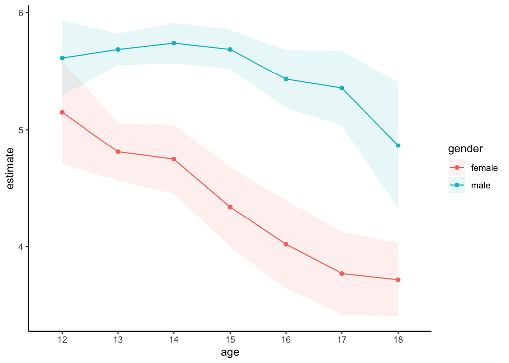

```r
# Plot over age
comp_gaming <- avg_predictions(media_usage_gaming, by = c("gender", "age"), vcov = ~ unique_classroom)
ggplot(data = comp_gaming, aes(y = estimate, x = age, group = gender, color = gender)) +
  geom_point() +
  geom_line() +
  geom_ribbon(alpha = .1, color = NA, aes(ymin = conf.low, ymax = conf.high, fill = gender)) +
  theme_classic()
```

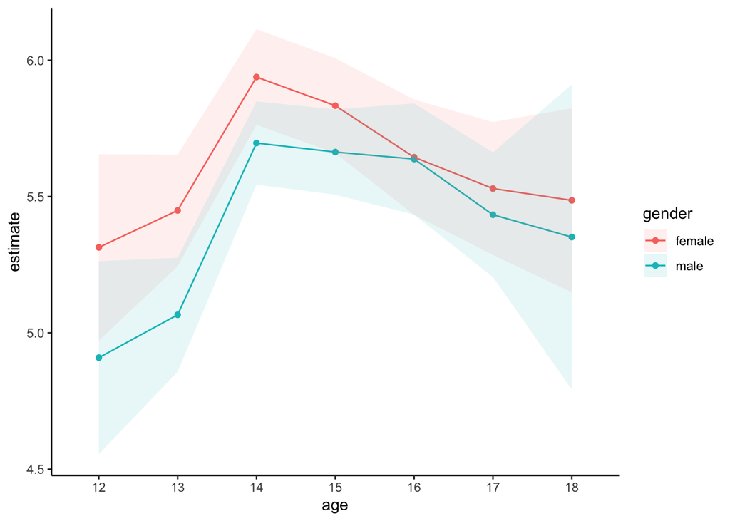

```r
comp_socialmedia <- avg_predictions(media_usage_socialmedia, by = c("gender", "age"), vcov = ~ unique_classroom)
ggplot(data = comp_socialmedia, aes(y = estimate, x = age, group = gender, color = gender)) +
  geom_point() +
  geom_line() +
  geom_ribbon(alpha = .1, color = NA, aes(ymin = conf.low, ymax = conf.high, fill = gender)) +
  theme_classic()
```

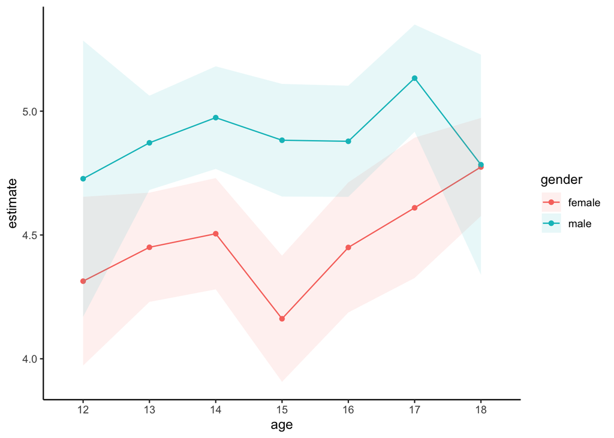

```r
comp_streaming <- avg_predictions(media_usage_streaming, by = c("gender", "age"), vcov = ~ unique_classroom)
ggplot(data = comp_streaming, aes(y = estimate, x = age, group = gender, color = gender)) +
  geom_point() +
  geom_line() +
  geom_ribbon(alpha = .1, color = NA, aes(ymin = conf.low, ymax = conf.high, fill = gender)) +
  theme_classic()
```

I’m not sure what’s the best way here to check whether gender differences in media usage can explain away the effects of survey mode. I guess if we look at girls who report as much gaming as boys, we should not observe that the survey mode affects them. This analysis seems problematic though if we assume that survey mode actually affects reported media usage! So maybe let’s keep that open for now and look at modification by age instead.